# RNA-seq Analysis in R

Annotation and Visualisation of RNA-seq results

Mark Dunning

Last modified: 10 Jan 2019

**Original Authors: Belinda Phipson, Anna Trigos, Matt Ritchie, Maria Doyle, Harriet Dashnow, Charity Law**, **Stephane Ballereau, Oscar Rueda, Ashley Sawle** Based on the course [RNAseq analysis in R](http://combine-australia.github.io/2016-05-11-RNAseq/) delivered on May 11/12th 2016

## Resources and data files

This material has been created using the following resources:  
http://www.statsci.org/smyth/pubs/QLedgeRPreprint.pdf (Lun, Chen, and Smyth 2016)  
http://monashbioinformaticsplatform.github.io/RNAseq-DE-analysis-with-R/99-RNAseq_DE_analysis_with_R.html  
http://bioconductor.org/packages/devel/bioc/vignettes/DESeq2/inst/doc/DESeq2.html https://bioconductor.github.io/BiocWorkshops/rna-seq-data-analysis-with-deseq2.html

Before starting this section, we will make sure we have all the relevant objects from the Differential Expression analysis present.

```r
suppressPackageStartupMessages(library(DESeq2))
load("Robjects/DE.Rdata")
load("Robjects/preprocessing.Rdata")
```

# Overview

We can now have a list of genes ordered according to their evidence for being differentially-expressed.

```r
library(dplyr)
library(tibble)
results.status <- as.data.frame(results(de.mf,contrast=c("Status","lactation","virgin"))) %>%
  rownames_to_column("ENSEMBL")

results.ordered <- arrange(results.status, padj)
head(results.ordered)
```

|  | ENSEMBL | baseMean | log2FoldChange | lfcSE | stat | pvalue | padj |
| --- | --- | --- | --- | --- | --- | --- | --- |
| 1 | ENSMUSG00000000381 | 398943.44 | 9.779005 | 0.4261732 | 22.94608 | 1.612341e-116 | 2.785481e-112 |
| 2 | ENSMUSG00000061937 | 1134857.22 | 8.204288 | 0.4158950 | 19.72683 | 1.268851e-86 | 1.096033e-82 |
| 3 | ENSMUSG00000026417 | 11320.43 | 6.589672 | 0.3634068 | 18.13304 | 1.748099e-73 | 1.006672e-69 |
| 4 | ENSMUSG00000022491 | 514850.04 | 9.589474 | 0.5336395 | 17.96995 | 3.350312e-72 | 1.447000e-68 |
| 5 | ENSMUSG00000061388 | 30555.67 | 10.172377 | 0.5858320 | 17.36398 | 1.546170e-67 | 5.342325e-64 |
| 6 | ENSMUSG00000024903 | 60039.52 | 8.772293 | 0.5388825 | 16.27868 | 1.398617e-59 | 4.027083e-56 |

In `DESeq2`, the function plotMA shows the log2 fold changes attributable to a given variable over the mean of normalized counts for all the samples in the DESeqDataSet. Points will be colored red if the adjusted p value is less than 0.1. Points which fall out of the window are plotted as open triangles pointing either up or down.

The log2 fold change for a particular comparison is plotted on the y-axis and the average of the counts normalized by size factor is shown on the x-axis (“M” for minus, because a log ratio is equal to log minus log, and “A” for average). Each gene is represented with a dot. Genes with an adjusted p value below a threshold (here 0.1, the default) are shown in red.

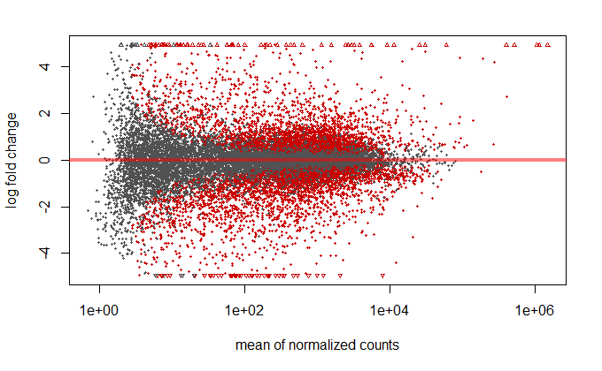

```r
plotMA(results(de.mf,contrast=c("Status","lactation","virgin")))
```

*Note* You may see an error message when trying to make the above MA plot. This could be because both `limma` and `DESeq2` have a function called `plotMA`, and R can sometimes pick the wrong function. To explictly use the `DESeq2` function you can use:-

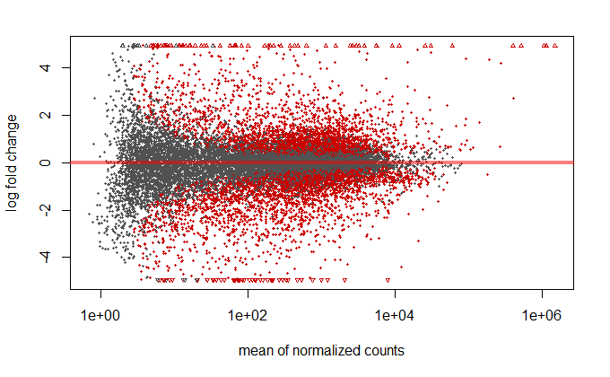

```r
DESeq2::plotMA(results(de.mf,contrast=c("Status","lactation","virgin")))
```

MA-plots often display a fanning-effect at the left-hand side (genes with low numbers of counts) due to the high variability of the measurements for these genes. For more informative visualization and more accurate ranking of genes by effect size (the log fold change may sometimes be referred to as an effect size), the `DESeq2` authors recommend “shrinking” the log fold-changes which is available in DESeq2’s `lfcShrink` function. This results in more stable fold change values. The p-values are unaffected.

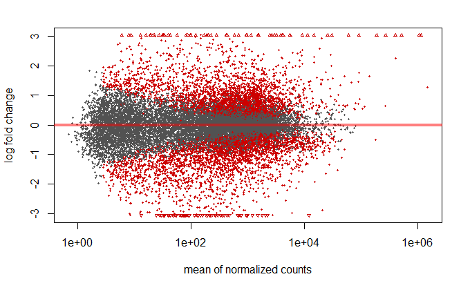

```r
res_LvsV <- lfcShrink(de.mf,contrast=c("Status","lactation","virgin"))
DESeq2::plotMA(res_LvsV)
```

We will re-define our results object to use these new fold-changes.

```r
results.ordered <- as.data.frame(res_LvsV) %>%
  rownames_to_column("ENSEMBL") %>%
  arrange(padj)
head(results.ordered)
```

|  | ENSEMBL | baseMean | log2FoldChange | lfcSE | stat | pvalue | padj |
| --- | --- | --- | --- | --- | --- | --- | --- |
| 1 | ENSMUSG00000000381 | 398943.44 | 8.722325 | 0.3815879 | 22.94608 | 1.612341e-116 | 2.785481e-112 |
| 2 | ENSMUSG00000061937 | 1134857.22 | 7.351405 | 0.3761569 | 19.72683 | 1.268851e-86 | 1.096033e-82 |
| 3 | ENSMUSG00000026417 | 11320.43 | 6.078220 | 0.3332017 | 18.13304 | 1.748099e-73 | 1.006672e-69 |
| 4 | ENSMUSG00000022491 | 514850.04 | 7.765956 | 0.4539439 | 17.96995 | 3.350312e-72 | 1.447000e-68 |
| 5 | ENSMUSG00000061388 | 30555.67 | 8.282907 | 0.4740455 | 17.36398 | 1.546170e-67 | 5.342325e-64 |
| 6 | ENSMUSG00000024903 | 60039.52 | 7.312158 | 0.4522371 | 16.27868 | 1.398617e-59 | 4.027083e-56 |

Another common plot for displaying the results of a differential expression analysis is a *volcano plot*

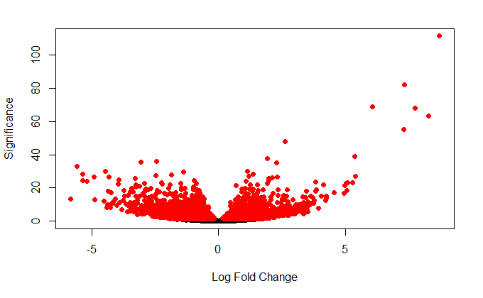

```r
plot(results.ordered$log2FoldChange, -log10(results.ordered$padj),
     pch=16,
     xlab="Log Fold Change",
       ylab="Significance")
degenes <- which(results.ordered$padj < 0.05)
points(results.ordered$log2FoldChange[degenes],-log10(results.ordered$padj)[degenes],
       col="red",
       pch=16)
```

It can also be useful to examine the counts of reads for a single gene across the groups. A simple function for making this plot is `plotCounts`, which normalizes counts by sequencing depth and adds a pseudocount of 1/2 to allow for log scale plotting. The counts are grouped by the variables in `intgroup`, where more than one variable can be specified. Here we specify the gene which had the smallest p value from the results table created above. You can select the gene to plot by rowname or by numeric index:-

```
using 'avgTxLength' from assays(dds), correcting for library size
```

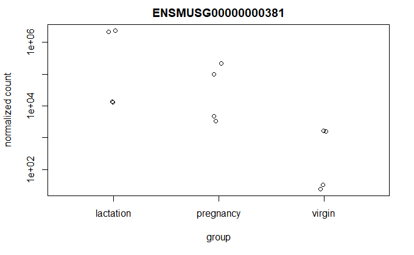

```r
plotCounts(dds, "ENSMUSG00000000381",intgroup = c("Status"))
```

## Adding annotation to the DESeq2 results

There are a number of ways to add annotation, but we will demonstrate how to do this using the *org.Mm.eg.db* package. This package is one of several *organism-level* packages which are re-built every 6 months. These packages are listed on the [annotation section](http://bioconductor.org/packages/release/BiocViews.html#___AnnotationData) of the Bioconductor, and are installed in the same way as regular Bioconductor packages. An alternative approach is to use `biomaRt`, an interface to the [BioMart](http://www.biomart.org/) resource. BioMart is much more comprehensive, but the organism packages fit better into the Bioconductor workflow.

```r
### Only execute when you need to install the package
source("http://www.bioconductor.org/biocLite.R")
biocLite("org.Mm.eg.db")
# For Human
biocLite("org.Hs.eg.db")
```

The packages are larger in size that Bioconductor software pacakges, but essentially they are databases that can be used to make *offline* queries.

```r
library(org.Mm.eg.db)
```

First we need to decide what information we want. In order to see what we can extract we can run the `columns` function on the annotation database.

```r
columns(org.Mm.eg.db)
```

```
 [1] "ACCNUM"       "ALIAS"        "ENSEMBL"      "ENSEMBLPROT"  "ENSEMBLTRANS"
 [6] "ENTREZID"     "ENZYME"       "EVIDENCE"     "EVIDENCEALL"  "GENENAME"
[11] "GO"           "GOALL"        "IPI"          "MGI"          "ONTOLOGY"
[16] "ONTOLOGYALL"  "PATH"         "PFAM"         "PMID"         "PROSITE"
[21] "REFSEQ"       "SYMBOL"       "UNIGENE"      "UNIPROT"
```

We are going to filter the database by a key or set of keys in order to extract the information we want. Valid names for the key can be retrieved with the `keytypes` function.

```r
keytypes(org.Mm.eg.db)
```

```
 [1] "ACCNUM"       "ALIAS"        "ENSEMBL"      "ENSEMBLPROT"  "ENSEMBLTRANS"
 [6] "ENTREZID"     "ENZYME"       "EVIDENCE"     "EVIDENCEALL"  "GENENAME"
[11] "GO"           "GOALL"        "IPI"          "MGI"          "ONTOLOGY"
[16] "ONTOLOGYALL"  "PATH"         "PFAM"         "PMID"         "PROSITE"
[21] "REFSEQ"       "SYMBOL"       "UNIGENE"      "UNIPROT"
```

We should see `ENSEMBL`, which is the type of key we are going to use in this case. If we are unsure what values are acceptable for the key, we can check what keys are valid with `keys`

```r
keys(org.Mm.eg.db, keytype="ENSEMBL")[1:10]
```

```
 [1] "ENSMUSG00000030359" "ENSMUSG00000020804" "ENSMUSG00000025375"
 [4] "ENSMUSG00000015243" "ENSMUSG00000028125" "ENSMUSG00000026944"
 [7] "ENSMUSG00000031333" "ENSMUSG00000024030" "ENSMUSG00000058835"
[10] "ENSMUSG00000026842"
```

For the top gene in our analysis the call to the function would be:-

```r
select(org.Mm.eg.db, keys="ENSMUSG00000000381",
       keytype = "ENSEMBL",columns=c("SYMBOL","GENENAME")
)


### In case of errors, try
### AnnotationDBI::select(org.Mm.eg.db, keys="ENSMUSG00000000381",keytype = "ENSEMBL",columns=c("SYMBOL","GENENAME")
```

To annotate our results, we definitely want gene symbols and perhaps the full gene name. Let’s build up our annotation information into a new data frame using the `select` function.

```r
anno <- AnnotationDbi::select(org.Mm.eg.db,keys=results.ordered$ENSEMBL,
              columns=c("SYMBOL","GENENAME"),
              keytype="ENSEMBL")
# Have a look at the annotation
anno
```

| ENSEMBL | SYMBOL | GENENAME |
| --- | --- | --- |
| ENSMUSG00000000381 | Wap | whey acidic protein |
| ENSMUSG00000061937 | Csn1s2a | casein alpha s2-like A |
| ENSMUSG00000026417 | Pigr | polymeric immunoglobulin receptor |
| ENSMUSG00000022491 | Glycam1 | glycosylation dependent cell adhesion molecule 1 |
| ENSMUSG00000061388 | Csn1s2b | casein alpha s2-like B |
| ENSMUSG00000024903 | Lao1 | L-amino acid oxidase 1 |
| ENSMUSG00000040260 | Daam2 | dishevelled associated activator of morphogenesis 2 |
| ENSMUSG00000070702 | Csn1s1 | casein alpha s1 |
| ENSMUSG00000063275 | Hacd1 | 3-hydroxyacyl-CoA dehydratase 1 |
| ENSMUSG00000024331 | Dsc2 | desmocollin 2 |

[output cut: 990 more lines]

However, we have a problem that the resulting data frame has more rows than our results table. This is due to the *one-to-many* relationships that often occur when mapping between various identifiers.

```r
dim(anno)
```

```
[1] 18086     3
```

```r
dim(results.ordered)
```

```
[1] 17973     7
```

Such duplicated entries can be identified using the `duplicated` function.

```r
dup_ids <- anno$ENSEMBL[duplicated(anno$ENSEMBL)]
filter(anno, ENSEMBL %in% dup_ids) %>%
  arrange(ENSEMBL)
```

| ENSEMBL | SYMBOL | GENENAME |
| --- | --- | --- |
| ENSMUSG00000000486 | Sept1 | septin 1 |
| ENSMUSG00000000486 | Gm4532 | predicted gene 4532 |
| ENSMUSG00000000562 | Adora3 | adenosine A3 receptor |
| ENSMUSG00000000562 | Tmigd3 | transmembrane and immunoglobulin domain containing 3 |
| ENSMUSG00000002250 | Ppard | peroxisome proliferator activator receptor delta |
| ENSMUSG00000002250 | 1810013A23Rik | RIKEN cDNA 1810013A23 gene |
| ENSMUSG00000003680 | Tmem179b | transmembrane protein 179B |
| ENSMUSG00000003680 | Taf6l | TATA-box binding protein associated factor 6 like |
| ENSMUSG00000003812 | Dnase2a | deoxyribonuclease II alpha |
| ENSMUSG00000003812 | Gm38426 | predicted gene, 38426 |

[output cut: 202 more lines]

Fortunately, there are not too many so hopefully we won’t lose too much information if we discard the entries that are duplicated. The first occurence of the duplicated ID will still be included in the table.

```r
anno <- AnnotationDbi::select(org.Mm.eg.db,keys=results.ordered$ENSEMBL,
              columns=c("ENSEMBL","SYMBOL","GENENAME","ENTREZID"),
              keytype="ENSEMBL") %>%
  filter(!duplicated(ENSEMBL))
dim(anno)
```

```
[1] 17973     4
```

We can bind in the annotation information to the `results` data frame.

```r
results.annotated <- left_join(results.ordered, anno,by="ENSEMBL")
results.annotated
```

| ENSEMBL | baseMean | log2FoldChange | lfcSE | stat | pvalue | padj | SYMBOL | GENENAME | ENTREZID |
| --- | --- | --- | --- | --- | --- | --- | --- | --- | --- |
| ENSMUSG00000000381 | 3.989434e+05 | 8.7223247 | 0.38158785 | 22.946083 | 1.612341e-116 | 2.785481e-112 | Wap | whey acidic protein | 22373 |
| ENSMUSG00000061937 | 1.134857e+06 | 7.3514049 | 0.37615692 | 19.726829 | 1.268851e-86 | 1.096033e-82 | Csn1s2a | casein alpha s2-like A | 12993 |
| ENSMUSG00000026417 | 1.132043e+04 | 6.0782204 | 0.33320169 | 18.133044 | 1.748099e-73 | 1.006672e-69 | Pigr | polymeric immunoglobulin receptor | 18703 |
| ENSMUSG00000022491 | 5.148500e+05 | 7.7659560 | 0.45394394 | 17.969948 | 3.350312e-72 | 1.447000e-68 | Glycam1 | glycosylation dependent cell adhesion molecule 1 | 14663 |
| ENSMUSG00000061388 | 3.055567e+04 | 8.2829065 | 0.47404548 | 17.363982 | 1.546170e-67 | 5.342325e-64 | Csn1s2b | casein alpha s2-like B | 12992 |
| ENSMUSG00000024903 | 6.003952e+04 | 7.3121584 | 0.45223712 | 16.278676 | 1.398617e-59 | 4.027083e-56 | Lao1 | L-amino acid oxidase 1 | 100470 |
| ENSMUSG00000040260 | 9.013451e+02 | 2.6210668 | 0.17281111 | 15.157501 | 6.759289e-52 | 1.668192e-48 | Daam2 | dishevelled associated activator of morphogenesis 2 | 76441 |
| ENSMUSG00000070702 | 1.058488e+06 | 5.3676599 | 0.39336234 | 13.750529 | 5.055822e-43 | 1.091805e-39 | Csn1s1 | casein alpha s1 | 12990 |
| ENSMUSG00000063275 | 9.273030e+02 | 1.9205109 | 0.14193105 | 13.529513 | 1.047149e-41 | 2.010060e-38 | Hacd1 | 3-hydroxyacyl-CoA dehydratase 1 | 30963 |
| ENSMUSG00000024331 | 2.758996e+02 | -2.4365206 | 0.18413142 | -13.200170 | 8.753699e-40 | 1.512289e-36 | Dsc2 | desmocollin 2 | 13506 |

[output cut: 990 more lines]

We can save the results table using the `write.csv` function, which writes the results out to a csv file that you can open in excel.

```r
write.csv(results.annotated,file="virgin_vs_lactation_DESeq_annotated.csv",row.names=FALSE)
```

The gene names that we have discovered can now be added to any plots that we have created. However, we still have to use the Ensembl IDs when accessing the `DESeqDataSet` object.

```
using 'avgTxLength' from assays(dds), correcting for library size
```

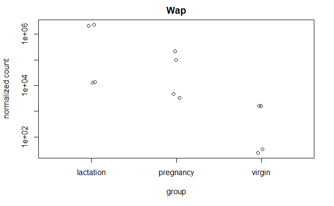

```r
plotCounts(dds, "ENSMUSG00000000381",intgroup = c("Status"),main="Wap")
```

We have already seen the use of a heatmap as a quality assessment tool to visualise the relationship between samples in an experiment. Another common use-case for such a plot is to visualise the results of a differential expression analysis….

Here we will take the top 10 genes from the differential expression analysis and produce a heatmap. The default colour palette goes from low expression in blue to high expression in red, which is a good alternative to the traditional red/green heatmaps which are not suitable for those with forms of colour-blindness.

```r
library(pheatmap)
top_genes <- results.annotated$ENSEMBL[1:10]
vsd <- vst(dds)
```

```
using 'avgTxLength' from assays(dds), correcting for library size
```

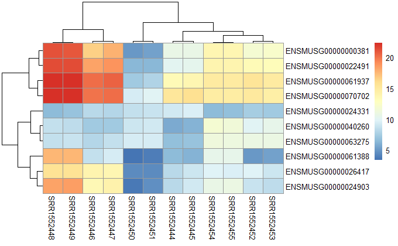

```r
pheatmap(assay(vsd)[top_genes,])
```

The heatmap is more informative if we add colours underneath the sample dendrogram to indicate which sample group each sample belongs to. This we can do by creating a data frame containing metadata for each of the samples in our dataset. With the `DESeq2` workflow we have already created such a data frame. We have to make sure the the rownames of the data frame are the same as the column names of the counts matrix.

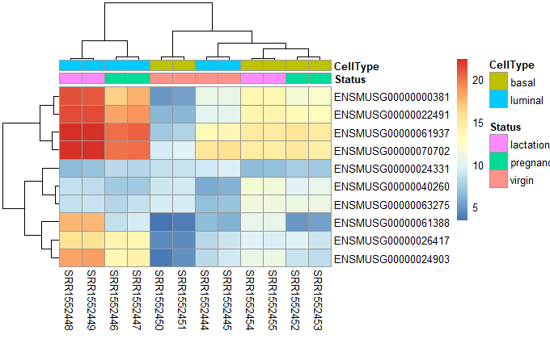

```r
sampleInfo <- as.data.frame(colData(dds)[,c("Status","CellType")])
pheatmap(assay(vsd)[top_genes,],
         annotation_col = sampleInfo)
```

Any plot we create in RStudio can be saved as a png or pdf file. We use the `png` or `pdf` function to create a file for the plot to be saved into and run the rest of the code as normal. The plot does not get displayed in RStudio, but printed to the specified file.

```r
png("heatmap_top10_genes.png",width=800,height=800)
pheatmap(assay(vsd)[top_genes,],
         annotation_col = sampleInfo)
# dev.off()
```

## Challenge 1

> 1. Repeat the same heatmap as above, but for the top 100 most differentially-expressed genes
> 2. Change the plot so that gene names are displayed rather than Ensembl IDs
> 3. Save the plot to a pdf file HINT: check the help for the `pheatmap` function to see how column and row labels can be changed

### Accessing the sample or gene clusters

The heatmap displays relationships between samples and genes in our study as a useful visualisation. In this example we can easily identify which samples are most similar based on their expression patterns. However, for larger dataset this may be more problematic. We can extract data the sample relationships about if we manually perform the clustering steps used by `pheatmap`. First is to cluster the samples with the default distance matrix and clustering algorithms.

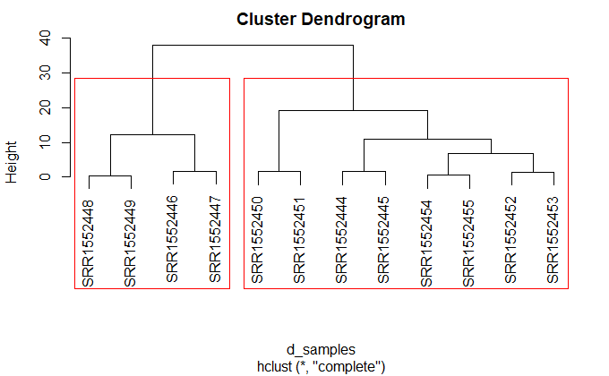

```r
mat <- assay(vsd)[top_genes,]
## Calculate the distance matrix between samples
d_samples <- dist(t(mat))
plot(hclust(d_samples))
rect.hclust(hclust(d_samples),k=2)
```

We can then “cut” the dendrogram to give a set number of clusters. Each sample has been assigned a label of `1` or `2` depending on which cluster it belongs to.

```r
clusters <- cutree(hclust(d_samples),k = 2)
clusters
```

```
SRR1552444 SRR1552445 SRR1552446 SRR1552447 SRR1552448 SRR1552449 SRR1552450
         1          1          2          2          2          2          1
SRR1552451 SRR1552452 SRR1552453 SRR1552454 SRR1552455
         1          1          1          1          1
```

The groupings could then be tabulated against with the sample metadata to see if particular biological groups are associated with the new clusters we have identified.

```r
table(clusters, colData(dds)$Status)
```

```
clusters lactation pregnancy virgin
       1         2         2      4
       2         2         2      0
```

A similar approach would also work for the genes. The key difference that we don’t transpose before calculating the distance matrix. For the small number of genes in the heatmap such a distance matrix can be computed, but it may be computationally-expensive for a large number of genes.

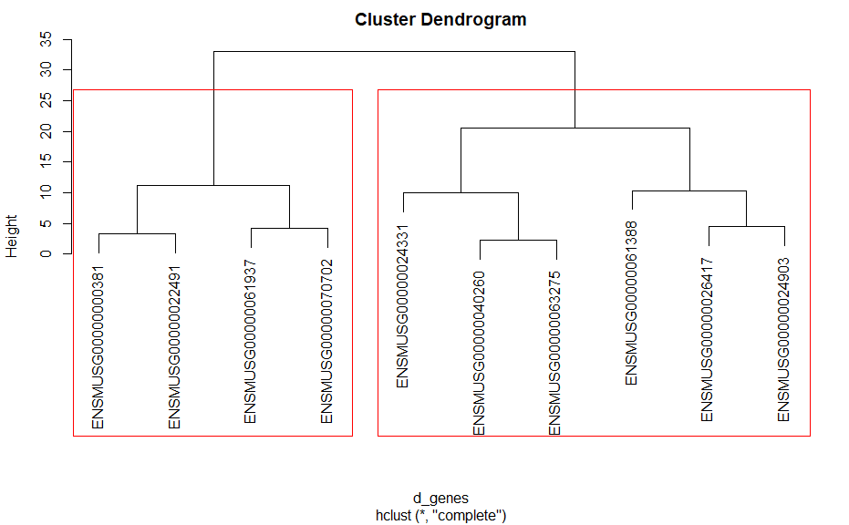

```r
d_genes <- dist(mat)
plot(hclust(d_genes))
## Do clustering and split the samples into 2 groups
rect.hclust(hclust(d_genes),k=2)
```

```r
cutree(hclust(d_genes),k = 2)
```

```
ENSMUSG00000000381 ENSMUSG00000061937 ENSMUSG00000026417 ENSMUSG00000022491
                 1                  1                  2                  1
ENSMUSG00000061388 ENSMUSG00000024903 ENSMUSG00000040260 ENSMUSG00000070702
                 2                  2                  2                  1
ENSMUSG00000063275 ENSMUSG00000024331
                 2                  2
```

### Annotation with the biomaRt resource

The Bioconductor package have the convenience of being able to make queries offline. However, they are only available for certain organisms. If your organism does not have an `org.XX.eg.db` package listed on the Bioconductor annotation page (http://bioconductor.org/packages/release/BiocViews.html#___AnnotationData), an alternative is to use biomaRt which provides an interface to the popular biomart annotation resource.

The first step is to find the name of a database that you want to connect to

```r
library(biomaRt)
listMarts()
```

| biomart | version |
| --- | --- |
| ENSEMBL_MART_ENSEMBL | Ensembl Genes 95 |
| ENSEMBL_MART_MOUSE | Mouse strains 95 |
| ENSEMBL_MART_SNP | Ensembl Variation 95 |
| ENSEMBL_MART_FUNCGEN | Ensembl Regulation 95 |

```r
ensembl=useMart("ENSEMBL_MART_ENSEMBL")
# list the available datasets (species). Replace mouse with the name of your organism
listDatasets(ensembl) %>% filter(grepl("Mouse",description))
```

| dataset | description | version |
| --- | --- | --- |
| mmurinus_gene_ensembl | Mouse Lemur genes (Mmur_3.0) | Mmur_3.0 |
| mmusculus_gene_ensembl | Mouse genes (GRCm38.p6) | GRCm38.p6 |

```r
ensembl = useDataset("mmusculus_gene_ensembl", mart=ensembl)
```

Queries to `biomaRt` are constructed in a similar way to the queries we performed with the `org.Mm.eg.db` package. Instead of `keys` we have `filters`, and instead of `columns` we have attributes. The list of acceptable values is much more comprehensive that for the `org.Mm.eg.db` package.

```r
listFilters(ensembl) %>%
    filter(grepl("ensembl",name))
```

| name | description |
| --- | --- |
| with_clone_based_ensembl_gene | With Clone-based (Ensembl) gene ID(s) |
| with_clone_based_ensembl_transcript | With Clone-based (Ensembl) transcript ID(s) |
| ensembl_gene_id | Gene stable ID(s) [e.g. ENSMUSG00000000001] |
| ensembl_gene_id_version | Gene stable ID(s) with version [e.g. ENSMUSG00000000001.4] |
| ensembl_transcript_id | Transcript stable ID(s) [e.g. ENSMUST00000000001] |
| ensembl_transcript_id_version | Transcript stable ID(s) with version [e.g. ENSMUST00000000001.4] |
| ensembl_peptide_id | Protein stable ID(s) [e.g. ENSMUSP00000000001] |
| ensembl_peptide_id_version | Protein stable ID(s) with version [e.g. ENSMUSP00000000001.4] |
| ensembl_exon_id | Exon ID(s) [e.g. ENSMUSE00000097910] |
| clone_based_ensembl_gene | Clone-based (Ensembl) gene ID(s) [e.g. AC026385.1] |

[output cut: 1 more lines]

```r
listAttributes(ensembl) %>%
    filter(grepl("gene",name))
```

| name | description | page |
| --- | --- | --- |
| ensembl_gene_id | Gene stable ID | feature_page |
| ensembl_gene_id_version | Gene stable ID version | feature_page |
| external_gene_name | Gene name | feature_page |
| external_gene_source | Source of gene name | feature_page |
| percentage_gene_gc_content | Gene % GC content | feature_page |
| gene_biotype | Gene type | feature_page |
| clone_based_ensembl_gene | Clone-based (Ensembl) gene ID | feature_page |
| entrezgene_trans_name | EntrezGene transcript name ID | feature_page |
| genedb | GeneDB ID | feature_page |
| entrezgene | NCBI gene ID | feature_page |

[output cut: 323 more lines]

An advantage over the `org..` packages is that positional information can be retrieved

```r
attributeNames <- c('ensembl_gene_id', 'entrezgene', 'external_gene_name')
getBM(attributes = attributeNames,
      filters = "ensembl_gene_id",
      values=top_genes,
      mart=ensembl)
```

| ensembl_gene_id | entrezgene | external_gene_name |
| --- | --- | --- |
| ENSMUSG00000000381 | 22373 | Wap |
| ENSMUSG00000022491 | 14663 | Glycam1 |
| ENSMUSG00000024331 | 13506 | Dsc2 |
| ENSMUSG00000024903 | 100470 | Lao1 |
| ENSMUSG00000026417 | 18703 | Pigr |
| ENSMUSG00000040260 | 76441 | Daam2 |
| ENSMUSG00000061388 | 12992 | Csn1s2b |
| ENSMUSG00000061937 | 12993 | Csn1s2a |
| ENSMUSG00000063275 | 30963 | Hacd1 |
| ENSMUSG00000070702 | 12990 | Csn1s1 |

## Challenge 2

> 1. Use biomaRt to create an data frame containing the entrezgene, gene symbol and genomic coordinates (chromosome, start, end) for the Ensembl IDs in the DESeq2 results
> 2. Remove duplicates entries from the new data frame
> 3. Join the biomaRt annotation to the DESeq2 results to produce a data frame with differential expression results and annotation
> 4. Write the joined data frame to a csv file

### Interactive graphs and tables

It is often useful to be able to explore our results in an interactive manner; searching for our favourite genes of interest and plotting on-the-fly whether they are statistically significant in our dataset or not.

Such a visualisation is possible with the [Glimma](https://academic.oup.com/bioinformatics/article-lookup/doi/10.1093/bioinformatics/btx094) Bioconductor package.

It takes our `DESeq2` results object, annotation table and normalized counts, and produces a HTML page including a sortable results table, MA-plot and scatter plot. Particular genes can be searched among the table and their expression patterns can be displayed. Alternatively we can click on particular point in the plot and display their stats.

```r
results <- results(de.mf,contrast=c("Status","lactation","virgin"))
## Repeat the annotation, as the previous annotation table was created using an ordered results table
anno <- AnnotationDbi::select(org.Mm.eg.db,keys=rownames(results),
              columns=c("SYMBOL","GENENAME"),
              keytype="ENSEMBL") %>%
  filter(!duplicated(ENSEMBL))
```

```r
## Make sure we have normalised counts before proceeding
dds <- estimateSizeFactors(dds)
```

```
using 'avgTxLength' from assays(dds), correcting for library size
```

```r
## Load the Glimma package and create the report
library(Glimma)
glMDPlot(results,
         anno,
         groups = colData(dds)$Status,
         counts = counts(dds,normalized=TRUE),
         transform = TRUE,
         side.main = "ENSEMBL")
```

### Brief Introduction to ggplot2

The [`ggplot2`](http://ggplot2.tidyverse.org/) package has emerged as an attractive alternative to the traditional plots provided by base R. A full overview of all capabilities of the package is available from the [cheatsheet](https://www.rstudio.com/wp-content/uploads/2015/03/ggplot2-cheatsheet.pdf).

The `plotCounts` function that we saw earlier can be adjusted to return the data associated with the plot, which in-turn can be passed to a `ggplot2` function for customisable plots.

- `plot_data` is our data frame containing the variables we wish to plot
- `aes` creates a mpping between the variables in our data frame to the *aes*thetic proprties of the plot
  - the x-axis is mapped to `Status`, y-axis is mapped to `count`
- `geom_point` specifies the particular type of plot we want (in this case a scatter plot)
  - see [the cheatsheet](https://www.rstudio.com/wp-content/uploads/2015/03/ggplot2-cheatsheet.pdf) for other plot types

```r
library(ggplot2)
plot_data <- plotCounts(dds, "ENSMUSG00000000381",intgroup = c("CellType","Status"),returnData = TRUE)
plot_data
```

|  | count | CellType | Status |
| --- | --- | --- | --- |
| SRR1552444 | 1.569482e+03 | luminal | virgin |
| SRR1552445 | 1.671109e+03 | luminal | virgin |
| SRR1552446 | 9.802440e+04 | luminal | pregnancy |
| SRR1552447 | 2.205304e+05 | luminal | pregnancy |
| SRR1552448 | 2.292659e+06 | luminal | lactation |
| SRR1552449 | 2.137836e+06 | luminal | lactation |
| SRR1552450 | 2.427758e+01 | basal | virgin |
| SRR1552451 | 3.357483e+01 | basal | virgin |
| SRR1552452 | 3.410069e+03 | basal | pregnancy |
| SRR1552453 | 4.660197e+03 | basal | pregnancy |

[output cut: 2 more lines]

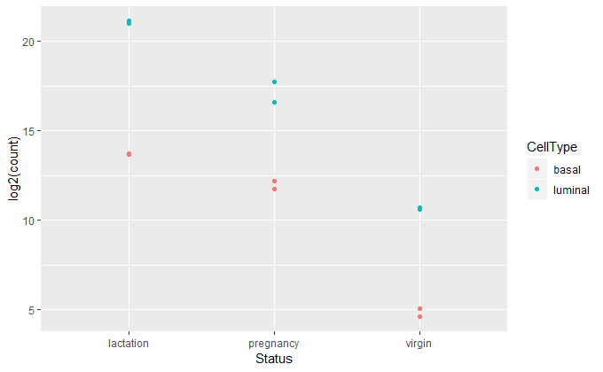

```r
ggplot(plot_data, aes(x = Status,y=log2(count),col=CellType)) + geom_point()
```

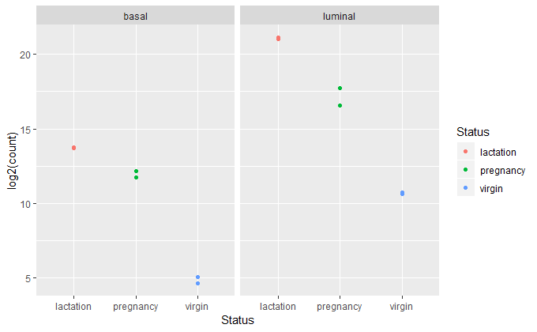

```r
ggplot(plot_data, aes(x = Status,y=log2(count),col=Status)) + geom_point()  + facet_wrap(~CellType)
```

A simple scatter plot, equivalent to `plotMA` from before, can be generated as follows:-

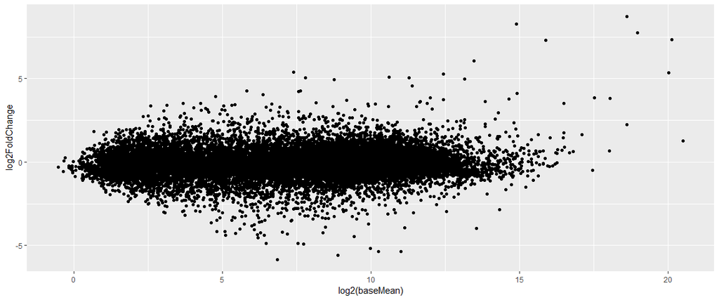

```r
library(ggplot2)
df <- results.annotated
ggplot(df, aes(x = log2(baseMean), y=log2FoldChange)) + geom_point()
```

The real advantage of `ggplot2` is the ability to change the appearance of our plot by mapping other variables to aspects of the plot. For example, we could colour the points based on a p-value cut-off. The colours are automatically chosen by `ggplot2`, but we can specifiy particular values.

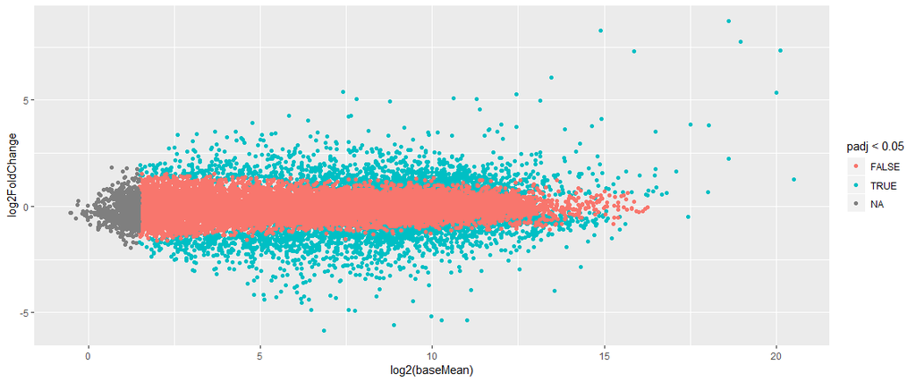

```r
ggplot(df, aes(x = log2(baseMean), y=log2FoldChange,col=padj<0.05)) + geom_point()
```

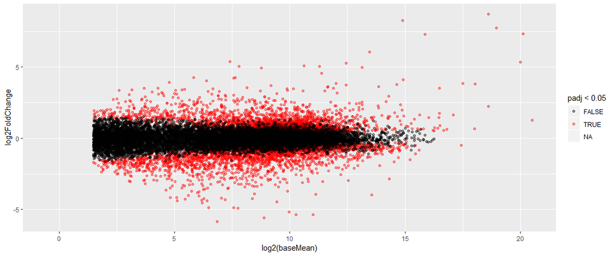

```r
ggplot(df, aes(x = log2(baseMean), y=log2FoldChange)) + geom_point(aes(color=padj<0.05),alpha=0.4) +  scale_colour_manual(values=c("black","red"))
```

Text can also be added to the plot to indicate the names of particular genes of interest. A column can be added to the data frame used for plotting with a text label that can be associated with each position on the plot. The plot would quickly become too cluttered if we added too many labels, but we can put empty strings `""` for genes that we don’t want to plot.

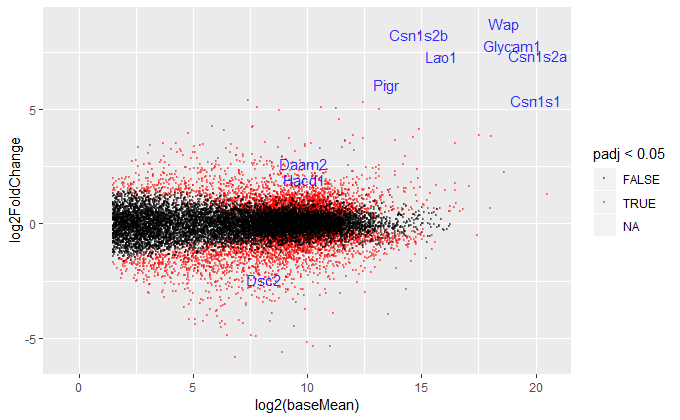

```r
N <- 10
top_genes <- df$ENSEMBL[1:N]
df<- mutate(df, Label=ifelse(df$ENSEMBL %in% top_genes, SYMBOL, ""))
ggplot(df, aes(x = log2(baseMean), y=log2FoldChange)) + geom_point(aes(color=padj<0.05),alpha=0.4,size=0.5) +  scale_colour_manual(values=c("black","red")) +  geom_text(aes(label=Label),col="blue",alpha=0.8)
```

Lun, Aaron T L, Yunshun Chen, and Gordon K Smyth. 2016. “It’s DE-licious: A Recipe for Differential Expression Analyses of RNA-seq Experiments Using Quasi-Likelihood Methods in edgeR.” *Methods in Molecular Biology (Clifton, N.J.)* 1418 (January): 391–416. doi:10.1007/978-1-4939-3578-9\_19.